# IAT Gender Career 2005

Alexander Porshnev

2023-08-21

# Gender & Career experiment IAT 2005-2022 (https://osf.io/abxq7/)

IAT task:

Female stimuli are: Rebecca, Michelle, Emily, Julia, Anna

Male stimuli are: Ben, Paul, Daniel, John, Jeffrey

Career stimuli are: Career, Corporation, Salary, Office, Professional, Management, Business

Family stimuli are: Wedding, Marriage, Parents, Relatives, Family, Home, Children

# Datasets & Variables

Participants variables with D, Mean RT, etc.

| Name | Comment |
| --- | --- |
| session_id | Seesion ID |
| D_biep.Male_Career_all | Overall IAT D score |
| D_biep.Male_Career_36 | IAT D score of block 3 and 6 |
| D_biep.Male_Career_47 | IAT D score of block 4 and 7 |
| Order | order of combined tasks |
| Side_Career_34 | Side where Career stimuli was first presented in IAT |
| Side_Male_34 | Side where Male stimuli was first presented in IAT |
| Mn_RT_all_3467 | Average latency of combined-task blocks |
| N_3467 | total number of trials in combined-task blocks |
| PCT_error_3467 | % of error in combined-task blocks |
| Mn_RT_all_3 | Mean latency of all trials in block 3 |
| Mn_RT_all_4 | Mean latency of all trials in block 4 |
| Mn_RT_all_6 | Mean latency of all trials in block 6 |
| Mn_RT_all_7 | Mean latency of all trials in block 7 |
| SD_all_3 | Standard Deviation of latency of all trials in block 3 |
| SD_all_4 | Standard Deviation of latency of all trials in block 4 |
| SD_all_6 | Standard Deviation of latency of all trials in block 6 |
| SD_all_7 | Standard Deviation of latency of all trials in block 7 |
| pct_300 | % of latencies below 300 ms |
| pct_400 | % of latencies below 400 ms |
| pct_2K | % of latencies below 2000 ms |
| pct_3K | % of latencies below 3000 ms |
| pct_4K | % of latencies below 4000 ms |
| N_3 | Number of trials in block 3 |
| N_4 | Number of trials in block 4 |
| N_5 | Number of trials in block 5 |
| N_6 | Number of trials in block 6 |
| N_7 | Number of trials in block 7 |
| Mn_RT_correct_3 | Mean latency of correct trials in block 3 |
| Mn_RT_correct_4 | Mean latency of correct trials in block 4 |
| Mn_RT_correct_6 | Mean latency of correct trials in block 6 |
| Mn_RT_correct_7 | Mean latency of correct trials in block 7 |
| SD_correct_3 | Standard Deviation of latency of correct trials in block 3 |
| SD_correct_4 | Standard Deviation of latency of correct trials in block 4 |
| SD_correct_6 | Standard Deviation of latency of correct trials in block 6 |
| SD_correct_7 | Standard Deviation of latency of correct trials in block 7 |
| N_ERROR_3 | Number of errors in block 3 |
| N_ERROR_4 | Number of errors in block 4 |
| N_ERROR_6 | Number of errors in block 6 |
| N_ERROR_7 | Number of errors in block 7 |
| age | Age |
| num | How many IATs have you previously performed? |
| sex | Gender |
| ethnic | Ethnicity |
| countrycit | Country/Region of Primary Citizenship |
| countryres | Country/Region of Residence |
| edu | original Education Level data |
| edu_13 | edu with a 13-point scale |
| edu_14 | edu with a 14-point scale |
| major | Major |
| politicalid | original Political Identity |
| politicalid_6 | politicalid with a 6-point scale |
| STATE | 2-letter State name for US residents |
| CountyNo | County No. for US residents |
| MSANo | Metropolitan Statistical Area No. for US residents |
| MSAName | Metropolitan Statistical Area Name for US residents |
| assocareer | How strongly do you associate career and family with males and females? Career |
| assofamily | How strongly do you associate career and family with males and females? Family |
| impcareer | How personally important are these domains to you? Career |
| impfamily | How personally important are these domains to you? Family |
| havechildren | Do you have children? |
| numboys | How many boys? |
| numgirls | How many girls? |
| planchildren | Do you plan to have children? |
| user_id | user id if registered |
| study_name | name of study |
| session_status | whether subject completed the study or not |
| previous_session_id | previous session id if subject toke another PI study within 15 min in the same browser |
| previous_session_schema | type of the previous study |
| month | Month of the session date |
| day | Day of the session date |
| year | Year of the session date |
| hour | Hour of the session date (24h format) |
| weekday | Weekday of the session date |
| date | Session date in SPSS Date format |

Long dataset (variables for each trial)

| block_number |
| --- |
| block_name |
| block_trial_count |
| block_pairing_definition |
| study_name |
| task_number |
| task_name |
| trial_number |
| trial_name |
| trial_response |
| trial_latency |
| trial_error |
| session_id |

N in datasets

| Np - participants in Gender-Career IAT.public.2005.csv | 60391 |
| --- | --- |
| Nt - trials in iat_2005.txt | 7100592 |
| trials per participant | 200 |
| expected Np*200 | 12078200 |
| missing | 4977608 |

# Check mean RT times calculations

RT - block 3

| session_id | Mn_RT_all_3 | M_block3 |
| --- | --- | --- |
| 1527646 | NA | NA |
| 1527664 | 584.45 | 584.45 |
| 1527689 | 838.55 | 838.55 |
| 1527692 | NA | NA |
| 1527704 | 809.20 | 809.20 |
| 1527735 | 1241.45 | 1241.45 |

RT - block 4

| session_id | Mn_RT_all_4 | M_block4 |
| --- | --- | --- |
| 1527646 | NA | NA |
| 1527664 | 579.800 | 579.800 |
| 1527689 | 757.800 | 757.800 |
| 1527692 | NA | NA |
| 1527704 | 651.625 | 651.625 |
| 1527735 | 853.325 | 853.325 |

RT - block 6

| session_id | Mn_RT_all_6 | M_block6 |
| --- | --- | --- |
| 1527646 | NA | NA |
| 1527664 | 638.85 | 638.85 |
| 1527689 | 625.70 | 625.70 |
| 1527692 | NA | NA |
| 1527704 | 851.75 | 851.75 |
| 1527735 | 831.60 | 831.60 |

| session_id | Mn_RT_all_7 | M_block7 |
| --- | --- | --- |
| 1527646 | NA | NA |
| 1527664 | 620.625 | 620.625 |
| 1527689 | 634.550 | 634.550 |
| 1527692 | NA | NA |
| 1527704 | 729.550 | 729.550 |
| 1527735 | 768.600 | 768.600 |

RT - blocks 3467

| session_id | Mn_RT_all_3467 | M_block3467 |
| --- | --- | --- |
| 1527646 | NA | NA |
| 1527664 | 604.0250 | 604.0250 |
| 1527689 | 708.1583 | 708.1583 |
| 1527692 | NA | NA |
| 1527704 | 737.2167 | 737.2167 |
| 1527735 | 886.1500 | 886.1500 |

# Participants’ countries available

Top 10 participants’ countries

| Var1 | Freq |
| --- | --- |
| US | 27662 |
|  | 19712 |
| . | 8644 |
| CA | 962 |
| UK | 579 |
| DE | 355 |
| AU | 217 |
| IN | 192 |
| NL | 161 |
| SE | 118 |

# Description of UK participants

Number of UK participants with D calculated

| Var1 | Freq |
| --- | --- |
| FALSE | 102 |
| TRUE | 477 |

UK participans (with D calculated): Disribution by gender

| Var1 | Freq |
| --- | --- |
|  | 3 |
| f | 328 |
| m | 146 |

Top 10, no differences occur

| session_id | PCT_error_3467 | errors | n | PCT_3467 |
| --- | --- | --- | --- | --- |
| 1527988 | 2.500000 | 3 | 120 | 2.500000 |
| 1561389 | 7.500000 | 9 | 120 | 7.500000 |
| 1561427 | 6.666667 | 8 | 120 | 6.666667 |
| 1585782 | 35.833333 | 43 | 120 | 35.833333 |
| 1605195 | 13.333333 | 16 | 120 | 13.333333 |
| 1605436 | 10.000000 | 12 | 120 | 10.000000 |

Errors rate lower than 10%

| Var1 | Freq |
| --- | --- |
| FALSE | 142 |
| TRUE | 332 |

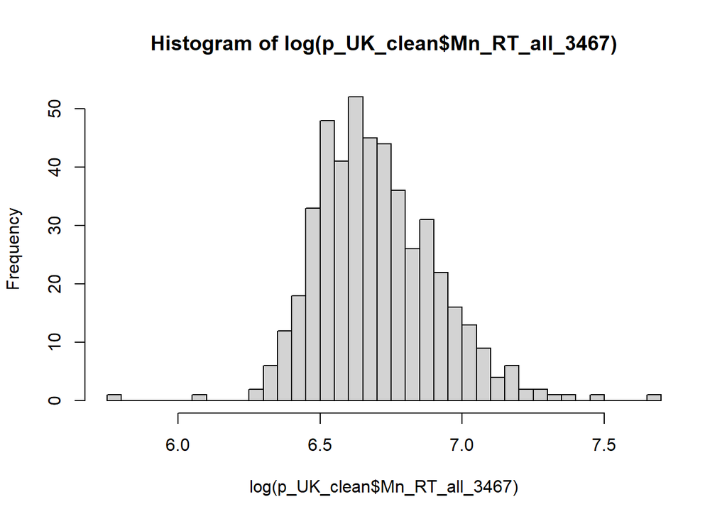

Errors in blocks 3,4,6,7

|  | vars | n | mean | sd | median | trimmed | mad | min | max | range | skew | kurtosis | se |
| --- | --- | --- | --- | --- | --- | --- | --- | --- | --- | --- | --- | --- | --- |
| X1 | 1 | 474 | 9.793249 | 7.918685 | 8 | 8.697368 | 5.9304 | 0 | 50 | 50 | 1.792828 | 4.648352 | 0.3637173 |

Mean Reaction time for blocks 3,4,6,7

|  | vars | n | mean | sd | median | trimmed | mad | min | max | range | skew | kurtosis | se |
| --- | --- | --- | --- | --- | --- | --- | --- | --- | --- | --- | --- | --- | --- |
| X1 | 1 | 474 | 830.7499 | 191.5694 | 795.0875 | 809.841 | 154.6537 | 323.3333 | 2100.908 | 1777.575 | 1.603822 | 5.51945 | 8.799074 |

# Suggested data cleaning filters

D_biep.Male_Career_all: D != NA

countryres: country of residence UK

sex: not empty field

Mn_RT_all_3467: mean RT outliers (log lover than 6 or higher than 7.5)

PCT_error_3467: less than 10% errors in blocks - 3467

age: young partipants (<18)

edu: not in “elementary school” or “junior high”

added variable

country_mig <- countrycit != “UK”

# Descriptive statitics for UK - 2005 clean sample

sex

| Var1 | Freq |
| --- | --- |
| f | 227 |
| m | 92 |

Order

| Var1 | Freq |
| --- | --- |
| 1 | 157 |
| 2 | 162 |

politicalid_6

| Var1 | Freq |
| --- | --- |
| 1 | 7 |
| 2 | 20 |
| 3 | 78 |
| 4 | 84 |
| 5 | 70 |
| 6 | 39 |

country_mig

| Var1 | Freq |
| --- | --- |
| FALSE | 251 |
| TRUE | 67 |

| Value | Freq | Category |
| --- | --- | --- |
| 3 | 6 | some high school |
| 4 | 23 | high school graduate |
| 5 | 75 | some college |
| 6 | 10 | associate’s degree |
| 7 | 100 | bachelor’s degree |
| 8 | 14 | some graduate school |
| 9 | 48 | master’s degree |
| 11 | 2 | M.D. |
| 12 | 16 | Ph.D. |
| 13 | 8 | other advanced degree |
| 14 | 10 | M.B.A. |

| Value | Freq | Category |
| --- | --- | --- |
| 2 | 10 | Asian or Pacific Islander |
| 3 | 7 | Black-Not of Hispanic Origin |
| 4 | 6 | Hispanic |
| 5 | 260 | White-Not of Hispanic Origin |
| 6 | 17 | Other or Unknown |
| 7 | 3 | Multi-racial (Black and White) |
| 8 | 8 | Multi-racial (other) |

| Value | Freq | Category |
| --- | --- | --- |
| 1 | 20 | Biological sciences/life sciences |
| 2 | 38 | Business |
| 3 | 2 | Communications |
| 4 | 12 | Computer and information sciences |
| 5 | 7 | Education |
| 6 | 25 | Engineering, mathematics, or physical sciences/science technologies |
| 7 | 8 | Health professions or related sciences |
| 8 | 37 | Humanities/liberal arts |
| 9 | 12 | Law or legal studies |
| 10 | 70 | Psychology |
| 11 | 29 | Social sciences or history |
| 12 | 12 | Visual or performing arts |
| 13 | 16 | Other |

|  | vars | n | mean | sd | median | trimmed | mad | min | max | range | skew | kurtosis | se |
| --- | --- | --- | --- | --- | --- | --- | --- | --- | --- | --- | --- | --- | --- |
| age | 1 | 319 | 29.7084639 | 10.5981319 | 27.0000000 | 28.4591440 | 10.3782000 | 18.000000 | 64.000000 | 46.000000 | 0.8769052 | -0.0108226 | 0.5933815 |
| Mn_RT_all_3467 | 2 | 319 | 841.9212121 | 180.3387219 | 804.2083333 | 821.6097276 | 161.3068800 | 550.433333 | 1786.275000 | 1235.841667 | 1.2974305 | 2.7214547 | 10.0970300 |
| PCT_error_3467 | 3 | 319 | 4.9268548 | 2.6777899 | 5.0000000 | 4.9221790 | 2.4710000 | 0.000000 | 10.000000 | 10.000000 | 0.0070715 | -0.9153773 | 0.1499275 |
| D_biep.Male_Career_all | 4 | 319 | 0.4281536 | 0.3677026 | 0.4541091 | 0.4454502 | 0.3669564 | -1.307802 | 1.402602 | 2.710404 | -0.7457644 | 1.8704780 | 0.0205874 |

|  | vars | n | mean | sd | median | trimmed | mad | min | max | range | skew | kurtosis | se |
| --- | --- | --- | --- | --- | --- | --- | --- | --- | --- | --- | --- | --- | --- |
| assocareer | 1 | 319 | 3.482759 | 0.7304155 | 3 | 3.435798 | 0.0000 | 1 | 5 | 4 | 0.1802122 | 0.2399794 | 0.0408954 |
| assofamily | 2 | 317 | 2.223975 | 0.7271798 | 2 | 2.223529 | 0.0000 | 1 | 5 | 4 | 0.5181625 | 0.8281164 | 0.0408425 |
| impcareer | 3 | 319 | 3.680251 | 0.9702907 | 4 | 3.758755 | 1.4826 | 1 | 5 | 4 | -0.5641184 | 0.1645280 | 0.0543259 |
| impfamily | 4 | 318 | 4.125786 | 0.9514534 | 4 | 4.253906 | 1.4826 | 1 | 5 | 4 | -1.0621558 | 0.8336434 | 0.0533549 |
| havechildren* | 5 | 319 | 2.194357 | 0.4341906 | 2 | 2.140078 | 0.0000 | 1 | 3 | 2 | 0.9460532 | 0.4181194 | 0.0243100 |
| numboys | 6 | 22 | 1.318182 | 0.4767313 | 1 | 1.277778 | 0.0000 | 1 | 2 | 1 | 0.7280987 | -1.5334711 | 0.1016395 |
| numgirls | 7 | 25 | 1.360000 | 0.7000000 | 1 | 1.238095 | 0.0000 | 1 | 3 | 2 | 1.5315219 | 0.7524845 | 0.1400000 |
| planchildren* | 8 | 319 | 2.893417 | 1.2316275 | 3 | 2.988327 | 1.4826 | 1 | 4 | 3 | -0.4821912 | -1.4379682 | 0.0689579 |

# D - comparison

D_biep.Male_Career - variable calculated for each participant in pre-processed file D - calculated from raw data (M1- M2)/sd(12)

[1] “Block 3 vs 6”

Similar values (top 10) from 316

| session_id | D_biep.Male_Career_36 | D |
| --- | --- | --- |
| 1527988 | 0.9328354 | 0.9328354 |
| 1561389 | 0.8463057 | 0.8463057 |
| 1561427 | 0.7692310 | 0.7692310 |
| 1605436 | 1.1891965 | 1.1891965 |
| 1608859 | 0.3217162 | 0.3217162 |
| 1609831 | -0.3118442 | -0.3118442 |

Differences, top 10 from 3

|  | session_id | D_biep.Male_Career_36 | D |
| --- | --- | --- | --- |
| 8 | 1610851 | -0.0737204 | 0.2928003 |
| 11 | 1624566 | 0.1251036 | 0.3114839 |
| 177 | 2657988 | -0.7380516 | -0.7277548 |

[1] “Block 4 vs 7”

Similar values (top 10) from 318

| session_id | D_biep.Male_Career_47 | D |
| --- | --- | --- |
| 1527988 | 0.7516852 | 0.7516852 |
| 1561389 | 0.4527089 | 0.4527089 |
| 1561427 | 0.7191203 | 0.7191203 |
| 1605436 | 0.5538967 | 0.5538967 |
| 1608859 | 0.1302582 | 0.1302582 |
| 1609831 | 0.3127709 | 0.3127709 |

Differences, top 10 from 1

|  | session_id | D_biep.Male_Career_47 | D |
| --- | --- | --- | --- |
| 69 | 1980886 | 0.3301675 | 0.3409709 |

[1] “Blocks 3&4 vs 6&7”

| session_id | D_biep.Male_Career_all | D |
| --- | --- | --- |
| 1527988 | 0.8422603 | 0.8109858 |
| 1561389 | 0.6495073 | 0.5949451 |
| 1561427 | 0.7441756 | 0.7173301 |
| 1605436 | 0.8715466 | 0.7802072 |
| 1608859 | 0.2259872 | 0.1971435 |
| 1609831 | 0.0004633 | 0.0475790 |

Differences, top 10 from 85

|  | session_id | D_biep.Male_Career_all | D |
| --- | --- | --- | --- |
| 6 | 1609831 | 0.0004633 | 0.0475790 |
| 8 | 1610851 | -0.0200951 | 0.1674167 |
| 11 | 1624566 | 0.3914384 | 0.4042464 |
| 16 | 1687673 | -0.2287274 | -0.1649222 |
| 18 | 1714254 | 0.2027641 | 0.2787973 |
| 28 | 1786347 | 0.8228499 | 0.8694835 |

[1] “Correlation D_biep.Male_Career_all & D_3467” [1] 0.9718565

Comparison of original D and Dmean from calculations

| D_biep.Male_Career_all | D_mean | D_3467 |
| --- | --- | --- |
| 0.8422603 | 0.8422603 | 0.8109858 |
| 0.6495073 | 0.6495073 | 0.5949451 |
| 0.7441756 | 0.7441756 | 0.7173301 |
| 0.8715466 | 0.8715466 | 0.7802072 |
| 0.2259872 | 0.2259872 | 0.1971435 |
| 0.0004633 | 0.0004633 | 0.0475790 |

|  | session_id | D_biep.Male_Career_all | D_3467 | D_biep.Male_Career_36 | D.x | D_biep.Male_Career_47 | D.y | D_mean |
| --- | --- | --- | --- | --- | --- | --- | --- | --- |
| 8 | 1610851 | -0.0200951 | 0.1674167 | -0.0737204 | 0.2928003 | 0.0335303 | 0.0335303 | 0.1631653 |
| 11 | 1624566 | 0.3914384 | 0.4042464 | 0.1251036 | 0.3114839 | 0.6577731 | 0.6577731 | 0.4846285 |

# Whole dataset D calculations (D_biep.Male_Career_all - NA removed)

[1] “Block 3 vs 6”

Similar values (top 10) from 33954

| session_id | D_biep.Male_Career_36 | D |
| --- | --- | --- |
| 1527664 | 0.2157190 | 0.2157190 |
| 1527689 | 0.7284629 | 0.7284629 |
| 1527704 | 0.1087143 | 0.1087143 |
| 1527735 | 0.6294956 | 0.6294956 |
| 1527763 | 0.2551996 | 0.2551996 |
| 1527780 | 0.3520655 | 0.3520655 |

Differences, top 10 from 165

|  | session_id | D_biep.Male_Career_36 | D |
| --- | --- | --- | --- |
| 267 | 1561690 | 0.1357950 | 0.3181231 |
| 471 | 1585552 | 0.5144318 | 0.5607427 |
| 509 | 1605112 | 0.0176469 | 0.3081971 |
| 527 | 1605331 | 0.1616005 | 0.3539682 |
| 599 | 1605976 | -0.4614547 | -0.2485263 |
| 605 | 1606086 | 0.0555321 | 0.3204564 |

[1] “Block 4 vs 7”

Similar values (top 10) from 33988

| session_id | D_biep.Male_Career_47 | D |
| --- | --- | --- |
| 1527664 | 0.2269210 | 0.2269210 |
| 1527689 | 0.8069228 | 0.8069228 |
| 1527704 | 0.3223115 | 0.3223115 |
| 1527735 | 0.2804192 | 0.2804192 |
| 1527763 | -0.1515696 | -0.1515696 |
| 1527780 | 0.6689923 | 0.6689923 |

Differences, top 10 from 131

|  | session_id | D_biep.Male_Career_47 | D |
| --- | --- | --- | --- |
| 104 | 1531802 | -0.1203497 | 0.1179337 |
| 159 | 1534961 | -0.0679513 | 0.2047700 |
| 329 | 1562469 | -0.0431835 | 0.2013753 |
| 843 | 1608428 | -0.5868883 | -0.3906639 |
| 864 | 1608690 | 0.2798421 | 0.3472385 |
| 898 | 1609161 | -0.1434455 | -0.0988045 |

[1] “Blocks 3&4 vs 6&7”

| session_id | D_biep.Male_Career_all | D |
| --- | --- | --- |
| 1527664 | 0.2213200 | 0.2203466 |
| 1527689 | 0.7676928 | 0.7319743 |
| 1527704 | 0.2155129 | 0.2164016 |
| 1527735 | 0.4549574 | 0.4204498 |
| 1527763 | 0.0518150 | -0.0689963 |
| 1527780 | 0.5105289 | 0.5201690 |

Differences, top 10 from 9111

|  | session_id | D_biep.Male_Career_all | D |
| --- | --- | --- | --- |
| 7 | 1527862 | 0.3541937 | 0.3937111 |
| 8 | 1527926 | 0.1485547 | 0.1725650 |
| 13 | 1528230 | 0.4849387 | 0.5194854 |
| 15 | 1528358 | 0.4289505 | 0.4430803 |
| 23 | 1528615 | -0.0145090 | 0.0515735 |
| 26 | 1528690 | 0.0153303 | 0.0296281 |

[1] 0.9694529

Comparison of original D and Dmean from calculations

| D_biep.Male_Career_all | D_mean | D_3467 |
| --- | --- | --- |
| 0.2213200 | 0.2213200 | 0.2203466 |
| 0.7676928 | 0.7676928 | 0.7319743 |
| 0.2155129 | 0.2155129 | 0.2164016 |
| 0.4549574 | 0.4549574 | 0.4204498 |
| 0.0518150 | 0.0518150 | -0.0689963 |
| 0.5105289 | 0.5105289 | 0.5201690 |

Differences, top 10 from 258

|  | session_id | D_biep.Male_Career_all | D_3467 | D_biep.Male_Career_36 | D.x | D_biep.Male_Career_47 | D.y | D_mean |
| --- | --- | --- | --- | --- | --- | --- | --- | --- |
| 104 | 1531802 | 0.1922099 | 0.1888047 | 0.5047695 | 0.5047695 | -0.1203497 | 0.1179337 | 0.3113516 |
| 159 | 1534961 | 0.0087172 | 0.1675492 | 0.0853857 | 0.0853857 | -0.0679513 | 0.2047700 | 0.1450779 |
| 267 | 1561690 | 0.4733556 | 0.3479706 | 0.1357950 | 0.3181231 | 0.8109162 | 0.8109162 | 0.5645196 |
| 329 | 1562469 | 0.1904134 | 0.2132303 | 0.4240104 | 0.4240104 | -0.0431835 | 0.2013753 | 0.3126929 |
| 471 | 1585552 | 0.7938132 | 0.5458536 | 0.5144318 | 0.5607427 | 1.0731946 | 1.0731946 | 0.8169686 |
| 509 | 1605112 | 0.2350584 | 0.2960858 | 0.0176469 | 0.3081971 | 0.4524699 | 0.4524699 | 0.3803335 |